# Project 1 Predictive Modeling

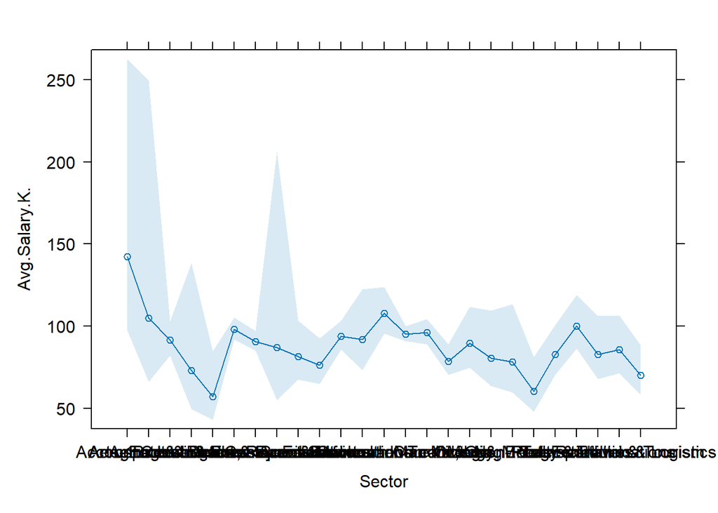

```r
#Sector
plot(effect(variables[[23]], first_glm), ci.style="band", rescale.axis=FALSE, multiline=TRUE, ylab="Avg.Salary.K.", rug=FALSE, main="")
```

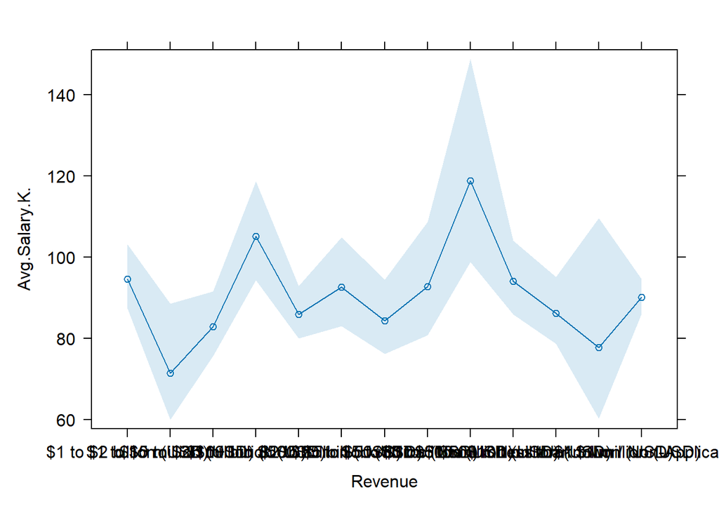

```r
#Revenue
plot(effect(variables[[24]], first_glm), ci.style="band", rescale.axis=FALSE, multiline=TRUE, ylab="Avg.Salary.K.", rug=FALSE, main="")
```

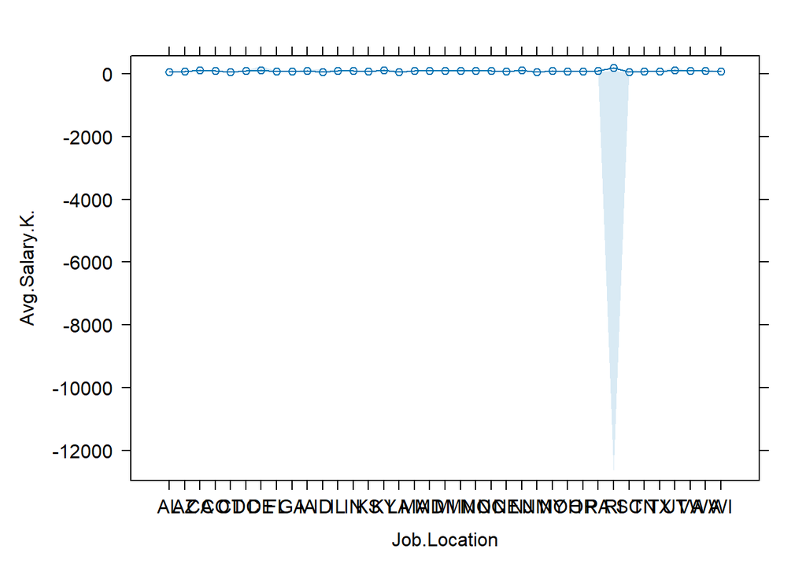

```r
#Job.Location
plot(effect(variables[[25]], first_glm), ci.style="band", rescale.axis=FALSE, multiline=TRUE, ylab="Avg.Salary.K.", rug=FALSE, main="")
```

As we can observe, after analyzing the individual effects of the variables on the model, we can get better inshigths. For example, variables as ‘job_title_sim’, ‘Hourly’, ‘Python’ or ‘Revenue’ gives many of the information to the model, as there is a clear difference between the values and the objective function and the intervals are well defined. However, other such as ‘sql’ or ‘Job.Location’ are not useful for the model, because there is a lot of uncertainty on the intervals and the mean salary value remains constant for all the x axis, so they are only adding noise.

We develop another model with the most informative variables (still without interactions). This model has lower $R^2$ value, so we will try on our final model add the necessary interactions to increase it by using only the necessary variables.

```r
## First glm
other_glm = glm(Avg.Salary.K. ~ job_title_sim + Hourly + Employer.provided   + google_an + Size + Type.of.ownership + Sector + Python + Revenue + sas, family = Gamma, data = Salary_data_Train)
#summary(first_glm)

pred_other_glm= predict(other_glm, newdata= Salary_data_Test)

#Let's know validate the predictions, calculating R^2 in the testing set

# Evaluate performance on the test set
R2_test <- cor(pred_other_glm, Salary_data_Test$Avg.Salary.K.)^2
RMSE_test <- sqrt(mean((pred_other_glm - Salary_data_Test$Avg.Salary.K.)^2))

cat("R-squared on test set:", R2_test, "\n")
```

```
## R-squared on test set: 0.3372371
```

```r
cat("RMSE on test set:", RMSE_test, "\n")
```

```
## RMSE on test set: 110.9552
```

### 3.3. Final model

After trying several combinations, we have reached to an $R^2 = 0.31$, close to the $R^2 = 0.39$ of the more complex model, but only using the most informative variables and the interactions between them. Let’s analyse the effects of them in the final model.

```r
## First glm
final_glm = glm(Avg.Salary.K. ~ job_title_sim*Python  + Sector + Revenue*sas , family = Gamma, data = Salary_data_Train)
#summary(first_glm)

pred_final_glm= predict(final_glm, newdata= Salary_data_Test)

#Let's know validate the predictions, calculating R^2 in the testing set

# Evaluate performance on the test set
R2_test <- cor(pred_final_glm, Salary_data_Test$Avg.Salary.K.)^2
RMSE_test <- sqrt(mean((pred_final_glm - Salary_data_Test$Avg.Salary.K.)^2))

cat("R-squared on test set:", R2_test, "\n")
```

```
## R-squared on test set: 0.3066056
```

```r
cat("RMSE on test set:", RMSE_test, "\n")
```

```
## RMSE on test set: 110.9553
```

#### 3.3.1. Effects

By using another library that supports the interactions of the model, we can observe the effects of each element on the GLM. Starting with the marginal component, ‘Sector’ is useful mainly for one category. Later, the interactions between ‘Python’ and ‘job_title_sim’ are much informative, having in mind the scale of the y axis. Also, ‘Revenue’ and ‘sas’ gives the objective variable much of the variance. All in all, this is a simpler model that from we started (then, it would not tend to overfit), but having most of the information of the application.

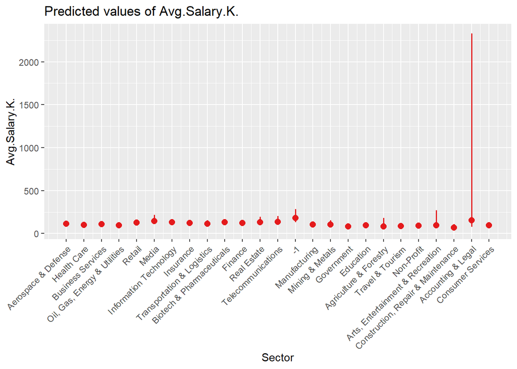

```r
#type pred: Predicted values (marginal effects) for specific model terms
#type int: Marginal effects of interaction terms in model
plot_model(final_glm, type = "pred", terms='Sector')+
  theme(axis.text.x = element_text(angle = 45, hjust = 1))
```

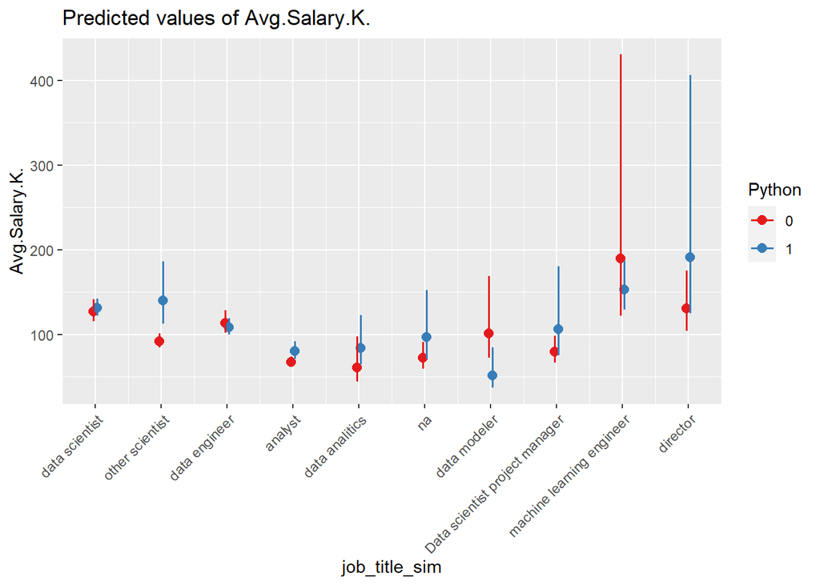

```r
plot_model(final_glm, type = "int")[[1]]+
  theme(axis.text.x = element_text(angle = 45, hjust = 1))
```

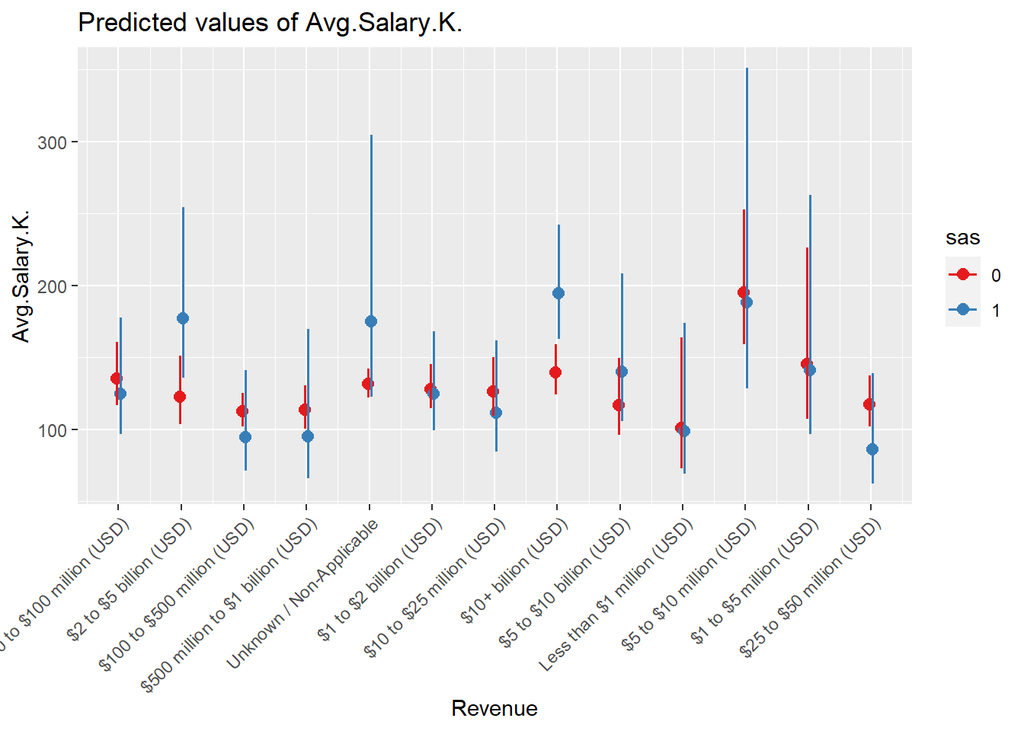

```r
plot_model(final_glm, type = "int")[[2]]+
  theme(axis.text.x = element_text(angle = 45, hjust = 1))
```

#### 3.3.2. Predictive performance and prediction intervals

We have already evaluated the $R^2$ and $RMSE$ values, let’s know plot the prediction intervals of the final model over the test set. We would follow two different approaches:

- Firstly, we would directly use the standard errors provided by the predict function for the gamma GLM model.
- Secondly, we would calculate the prediction intervals by transforming the bounds on the linear scale using the inverse link function of the gamma distribution.

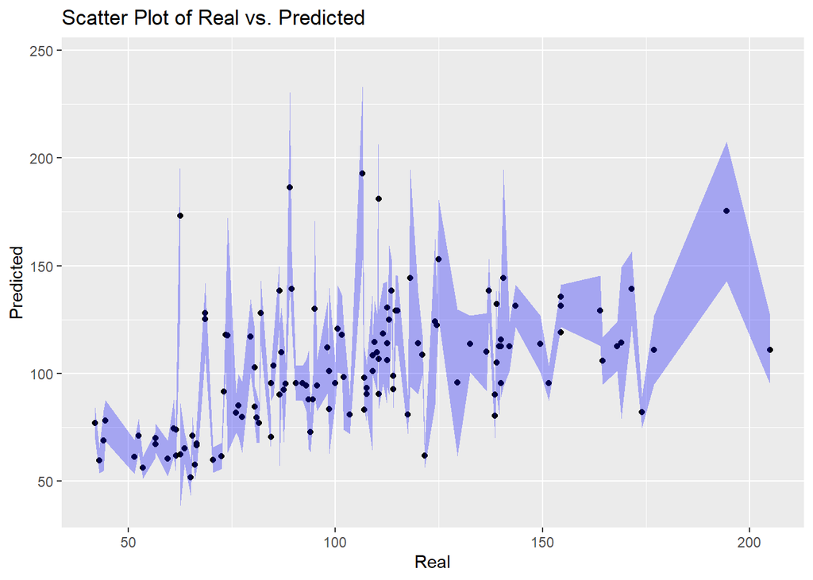

```r
##First approach
pred_final_glm= predict(final_glm, newdata= Salary_data_Test, type = "response", se.fit = TRUE)

# Create a data frame for plotting
plot_data <- data.frame(Real = Salary_data_Test$Avg.Salary.K.,
                        Pred =  pred_final_glm$fit,
                        Lower = pred_final_glm$fit - 1.96 * pred_final_glm$se.fit,
                        Upper = pred_final_glm$fit + 1.96 * pred_final_glm$se.fit)
# Prediction Interval Plot
ggplot(plot_data, aes(x = Real, y = Pred)) +
  geom_point() +
  geom_ribbon(aes(ymin = Lower, ymax = Upper), alpha = 0.3, fill = "blue") +
  labs(title = "Scatter Plot of Real vs. Predicted",
       x = "Real",
       y = "Predicted")
```

```r
# Counting the points outside the intervals
outside_interval_count <- sum(Salary_data_Test$Avg.Salary.K. < pred_final_glm$fit - 1.96 * pred_final_glm$se.fit | Salary_data_Test$Avg.Salary.K. > pred_final_glm$fit + 1.96 * pred_final_glm$se.fit)

# Calculating the coverage
total_points <- nrow(Salary_data_Test)
coverage <- round(100-(outside_interval_count / total_points) * 100, digits=1)

# Printing the coverage
print(paste("Percentage of points inside the intervals approach 1 :", coverage, "%"))
```

```
## [1] "Percentage of points inside the intervals approach 1 : 43.1 %"
```

Althougt on the plot we could visualize good predictions, when counting the points inside the intervals we get less that half of them. Let’s now evaluate the second approach.

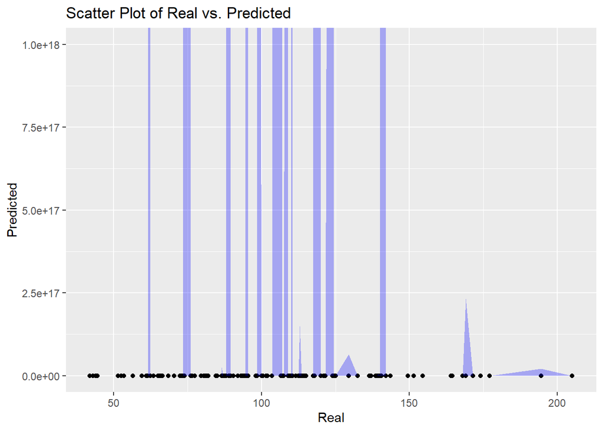

```r
## Second approach

# Extract necessary information
fit <- pred_final_glm$fit
se_fit <- pred_final_glm$se.fit

# Calculate prediction intervals using the inverse link function and Gamma distribution properties
lower_limit <- fit * exp(-1.96 * se_fit)
upper_limit <- fit * exp(1.96 * se_fit)

# Create a data frame for plotting
plot_data <- data.frame(
  Real = Salary_data_Test$Avg.Salary.K.,
  Pred = fit,
  Lower = lower_limit,
  Upper = upper_limit
)

y_limits <- c(0, 10^18)
ggplot(plot_data, aes(x = Real, y = Pred)) +
  geom_point() +
  geom_ribbon(aes(ymin = Lower, ymax = Upper), alpha = 0.3, fill = "blue") +
  labs(title = "Scatter Plot of Real vs. Predicted",
       x = "Real",
       y = "Predicted")+  coord_cartesian(ylim = y_limits)
```

```r
# Counting the points inside the intervals
inside_interval_count <- sum(Salary_data_Test$Avg.Salary.K. > lower_limit & Salary_data_Test$Avg.Salary.K. < upper_limit)

# Calculating the coverage
total_points <- nrow(Salary_data_Test)
coverage <- round((inside_interval_count / total_points) * 100, digits = 1)

# Printing the coverage
print(paste("Percentage of points inside the intervals approach 2:", coverage, "%"))
```

```
## [1] "Percentage of points inside the intervals approach 2: 100 %"
```

For the sake of interpretation, the first approach is better, however, second approach gives us better prediction results. In general, we could say that our final model has achieved to predict at least as well as the benchmark, as the RMSE are equal, and has achieved to predict inside the prediction intervals in most of the cases.

# Conclusions

In conclusion, this notebook outlines two distinct approaches to modeling a predictive application. In the context of the selected datasets, linear regression presents challenges in enhancing the benchmark, yet the final model successfully captures the majority of data points within the prediction intervals.

Conversely, Generalized Linear Models prove to be more adept at fitting the data distribution, yielding results comparable to the benchmark and encompassing the majority of data points within the prediction intervals.

In both scenarios, we emphasize the significance of interactions and variable selection. These aspects play a crucial role in developing a model that maximizes information while minimizing the impact of noise, thereby contributing to a more robust and reliable predictive framework.